# Transcriptome Profile

Justin Bogias

01 Aug, 2024

```r
library(tidyverse)
library(magrittr)
library(ggplot2)
library(edgeR)
library(viridisLite)
library(pheatmap)
library(VennDiagram)
library(grid)
library(gridExtra)
library(AnnotationHub)
library(ensembldb)
library(DT)
library(here)
```

# Import annotations

Load in the ensembl gene annotations here to be used throughout the DTE analysis. This will connect to an ensembl annotation database in which the ensembl version 99 metadata will be stored as an object, giving information on the transcript ID, length, gc content, biotype and other information. This step may take some time as the data can be somewhat large.

```r
ah <- AnnotationHub()

ensDb <- ah[["AH78783"]]
genesGR <- genes(ensDb)
transGR <- transcripts(ensDb)
transGR$gene_name <- mcols(genesGR)[mcols(transGR)$gene_id,"gene_name"]
transGR$length <- lengthOf(ensDb, "tx")

ensDb <- ah[["AH10684"]]
transcript_names <- ensDb %>%
  as.data.frame() %>%
  dplyr::filter(type == "transcript") %>%
  dplyr::select("transcript_id",
                "transcript_name")

grch38_txp_anno <- transGR %>%
  as.data.frame() %>%
  dplyr::select("gene_id",
                "gene_name",
                "transcript_id" = "tx_id",
                "width",
                "length",
                "chromosome" = "seqnames",
                "transcript_biotype" = "tx_biotype") %>%
  left_join(transcript_names,
            by = "transcript_id") %>%
  as_tibble()

grch38_gene_anno <- genesGR %>%
  as.data.frame() %>%
  dplyr::select("gene_id",
                "gene_name",
                "length" = "width",
                "chromosome" = "seqnames",
                "gene_biotype") %>%
  as_tibble()

ensDb <- ah[["AH10684"]]
transcript_names <- ensDb %>%
  as.data.frame() %>%
  dplyr::filter(type == "transcript") %>%
  dplyr::select("transcript_id",
                "transcript_name")
```

# Load data

Load the results from each analysis

```r
oxygenGenes <- read_csv(here("data/results/oxygenGenes.csv.gz"))
oxygenTranscripts <- read_csv(here("data/results/oxygenTranscripts.csv.gz"))
oxygenDTU <- read_csv(here("data/results/oxygenDTU.csv.gz"))

dtelist <- read_rds(here("data/counts/dtelist.rds"))

impure_samples <- c(
  "PAC006", "PAC008", "PAC024", "PAC025",
  "PAC034", "PAC035", "PAC039", "PAC041",
  "PAC036", "PAC045", "PAC071", "PAC131"
  )

pd <- here("data/metadata/metadata.csv") %>%
  read_csv() %>%
  dplyr::filter(Cohort == "PAC") %>%
  mutate(Trimester = as.factor(Trimester),
         Timepoint = ifelse(GestationalAge <= 10, "6-10weeks", "11-23weeks")) %>%
  dplyr::filter(!ID %in% impure_samples) %>%
  arrange(ID)

# metadata needs to be in this structure
age_order <- dplyr::arrange(pd, as.numeric(GestationalAge)) %>%
  dplyr::select(ID, GestationalAge)
```

# Figure 2 - Venn diagram

first we need to create subsets of the genes and transcripts which are considered to be differentially expressed. With these subsetted lists we can overlap and record just how similar each one is.

```r
sig_genes <- oxygenGenes %>%
  dplyr::filter(FDR < 0.05 & abs(logFC) > 1)

sig_tx <- oxygenTranscripts %>%
  dplyr::filter(FDR < 0.05 & abs(logFC) > 1)

sig_dtu <- oxygenDTU %>%
  dplyr::filter(geneFDR < 0.05)
```

Prepare objects to call in venn diagram, each object is essentially a list of genes which is featured in each different list. These recorded lists will be overlapped and the number of genes which feature in each of the different lists. Here, take the genes that transcribe significant transcripts in both the differential transcript expression and differential transcript usage results.

```r
DTE_DTU <- sig_dtu %>%
  dplyr::filter(Gene %in% sig_tx$Gene) %>%
  dplyr::select(Gene) %>%
  distinct() %>%
  as.matrix() %>%
  length()

sig_dtu %>%
  dplyr::filter(Gene %in% sig_tx$Gene,
                !Gene %in% sig_genes$Gene) %>%
  dplyr::select(Gene) %>%
  distinct() %>%
  as.matrix() %>%
  length() %>%
  print()
```

```
## [1] 50
```

```r
sig_dtu %>%
  dplyr::filter(Transcript %in% sig_tx$Transcript,
                !Gene %in% sig_genes$Gene) %>%
  dplyr::select(Gene) %>%
  distinct() %>%
  as.matrix() %>%
  length() %>%
  print()
```

```
## [1] 47
```

```r
dte_dtu_gene <- sig_dtu %>%
  dplyr::filter(Gene %in% sig_tx$Gene,
                !Gene %in% sig_genes$Gene) %>%
  dplyr::select(Gene) %>%
  distinct()

dte_dtu_tx <- sig_dtu %>%
  dplyr::filter(Transcript %in% sig_tx$Transcript,
                !Gene %in% sig_genes$Gene) %>%
  dplyr::select(Gene) %>%
  distinct()

extra_genes <- dte_dtu_gene %>%
  dplyr::filter(!Gene %in% dte_dtu_tx$Gene)

sig_dtu %>%
  dplyr::filter(Gene %in% sig_tx$Gene,
                !Gene %in% sig_genes$Gene) %>%
  dplyr::filter(Gene %in% extra_genes$Gene) %>%
  dplyr::select("Gene",
                "Gene Name" = "gene_name",
                "Transcript",
                "Transcript Name" = "transcript_name",
                "DTU gene FDR" = "geneFDR",
                "DTU transcript FDR" = "txpFDR") %>%
  left_join(oxygenTranscripts %>%
              dplyr::select("Transcript", "DTE FDR" = "FDR"),
            by = "Transcript") %>%
  datatable()
```

|  | Gene | Gene Name | Transcript | Transcript Name | DTU gene FDR | DTU transcript FDR | DTE FDR |
| --- | --- | --- | --- | --- | --- | --- | --- |
| 1 | ENSG00000155096 | AZIN1 | ENST00000520402 | AZIN1-013 | 0.00191537753853079 | 0.0002684952444637184 | 0.9999999993598144 |
| 2 | ENSG00000155096 | AZIN1 | ENST00000337198 | AZIN1-001 | 0.00191537753853079 | 0.06022378525744129 | 0.9999999993598144 |
| 3 | ENSG00000155096 | AZIN1 | ENST00000347770 | AZIN1-002 | 0.00191537753853079 | 0.989329281338988 | 0.9999999993598144 |
| 4 | ENSG00000124467 | PSG8 | ENST00000404209 | PSG8-001 | 0.00576725487211395 | 0.00882207571468191 | 0.0515138227363405 |
| 5 | ENSG00000124467 | PSG8 | ENST00000478387 | PSG8-006 | 0.00576725487211395 | 0.01391271969047028 | 0.990552136558955 |
| 6 | ENSG00000124467 | PSG8 | ENST00000600709 | PSG8-010 | 0.00576725487211395 | 0.763352102274187 | 0.2708145593366028 |
| 7 | ENSG00000124467 | PSG8 | ENST00000593692 | PSG8-004 | 0.00576725487211395 | 1 | 0.03332310951208294 |
| 8 | ENSG00000231924 | PSG1 | ENST00000403380 | PSG1-003 | 0.03397268005504029 | 0.03395449725638874 | 0.0590787665176876 |
| 9 | ENSG00000231924 | PSG1 | ENST00000244296 | PSG1-002 | 0.03397268005504029 | 0.1487093082014945 | 0.8572941655802817 |
| 10 | ENSG00000231924 | PSG1 | ENST00000436291 | PSG1-001 | 0.03397268005504029 | 1 | 0.7977277552189823 |

Now check for genes that are DGE and DTU but not found in DTE

```r
DGE_DTU <- sig_dtu %>%
  dplyr::filter(Gene %in% sig_genes$Gene) %>%
  dplyr::select(Gene) %>%
  distinct() %>%
  as.matrix() %>%
  length()

sig_dtu %>%
  dplyr::filter(Gene %in% sig_genes$Gene,
                !Gene %in% sig_tx$Gene) %>%
  nrow() %>%
  print()
```

```
## [1] 0
```

Now identify triply overlap genes

```r
DGE_DTE_DTU <- sig_dtu %>%
  dplyr::filter(Gene %in% sig_tx$Gene,
                Gene %in% sig_genes$Gene) %>%
  dplyr::select(Gene) %>%
  distinct() %>%
  as.matrix() %>%
  length()

sig_dtu %>%
  dplyr::filter(Gene %in% sig_tx$Gene,
                Gene %in% sig_genes$Gene) %>%
  dplyr::select(Gene) %>%
  distinct() %>%
  as.matrix() %>%
  length() %>%
  print()
```

```
## [1] 27
```

Now for genes in both DTE and DGE

```r
DTE_DGE <- sig_genes %>%
  dplyr::filter(Gene %in% sig_tx$Gene) %>%
  dplyr::select(Gene) %>%
  distinct() %>%
  as.matrix() %>%
  length()

sig_genes %>%
  dplyr::filter(Gene %in% sig_tx$Gene) %>%
  dplyr::select(Gene) %>%
  distinct() %>%
  as.matrix() %>%
  length() %>%
  print()
```

```
## [1] 634
```

Now get total numbers for the area parameters

```r
DGE_number <- sig_genes$Gene %>%
  unique() %>%
  length()

DTE_number <- sig_tx$Gene %>%
  unique() %>%
  length()

DTU_number <- sig_dtu$Gene %>%
  unique() %>%
  length()
```

The objects created in the previous code chunck are used here to plot the triple venn diagram which records the level of overlap between each of the different analyses run.

```r
# Lets draw a triple venn now
# cat.cex changed from 5 to 3.5
png(filename = here("data/figures/Figure_2.png"),
    width = 27.5,
    height = 21.725,
    units = "cm",
    res = 300)

grid.newpage()

v <- draw.triple.venn(
  area1 = DGE_number,
  area2 = DTE_number,
  area3 = DTU_number,
  n12 = DTE_DGE,
  n13 = DGE_DTU,
  n23 = DTE_DTU,
  n123 = DGE_DTE_DTU,
  category = c(
    "DGE",
    "DTE",
    "DTU"),
  fill = c(
    "blue",
    "red",
    "green"),
  lty = "blank",
  cex = 2,
  fontfamily = "sans",
  cat.fontfamily = "sans",
  cat.pos = c(200, 160, 360),
  cat.dist = c(0.05, 0.06, 0.075),
  cat.cex = 2,
  scaled = FALSE
)

grid.arrange(
  gTree(children = v),
  top = textGrob("Overlap of significant genes from DGE, DTE, and DTU analysis",
                 gp = gpar(fontsize = 22,
                           font = 2),
                 vjust = 1.5)
)

dev.off()
```

# Figure 3 - Greatest Differences

In this section I compare the DGE and DTE results in order to find which transcripts are most genuinly masked by aggregation to the gene level. Previously I had used the STAR counts from Jimmy’s paper but have instead opted to aggregate my transcript counts to the gene level to see the effect of the going from the transcript-level to the gene-level

```r
DET_DEG_logFC_diff <- oxygenTranscripts %>%
  dplyr::select("Transcript",
                "Gene",
                "GeneName",
                "logCPM",
                "logFC",
                "FDR") %>%
  left_join(oxygenGenes %>%
              dplyr::select(
                "Gene",
                "gene_logFC" = "logFC",
                "geneFDR" = "FDR"
              ),
            by = "Gene") %>%
  left_join(transcript_names,
            by = c("Transcript" = "transcript_id")) %>%
  mutate(logFC_diff = (abs(logFC) - abs(gene_logFC))) %>%
  arrange(desc(logFC_diff))

DET_DEG_logFC_diff %>% dplyr::filter(logFC_diff > 1) %>%
  dplyr::filter(geneFDR > 0.05 & abs(gene_logFC) < 1) %>%
  dplyr::select(
    "Transcript ID" = "Transcript",
    "Transcript Name" = "transcript_name",
    "Gene Name" = "GeneName",
    "txp logFC" = "logFC",
    "logFC Diff" = "logFC_diff",
    "txp FDR" = "FDR",
    "gene FDR" = "geneFDR"
  ) %>%
  write_csv(here("data/results/top_difference.csv"))

significance_diff <- DET_DEG_logFC_diff %>% dplyr::filter(geneFDR > 0.05)

DET_DEG_logFC_diff %>%
  dplyr::filter(is.na(geneFDR)) %>%
  dplyr::select(
    "Transcript ID" = "Transcript",
    "Transcript Name" = "transcript_name",
    "Gene Name" = "GeneName",
    "logFC",
    "FDR"
  ) %>%
  write_csv(here("data/results/txp_only.csv"))
```

Can we do the test? If the logFCs are in the opposite direction, some differences in logFC would be telling us the wrong thing

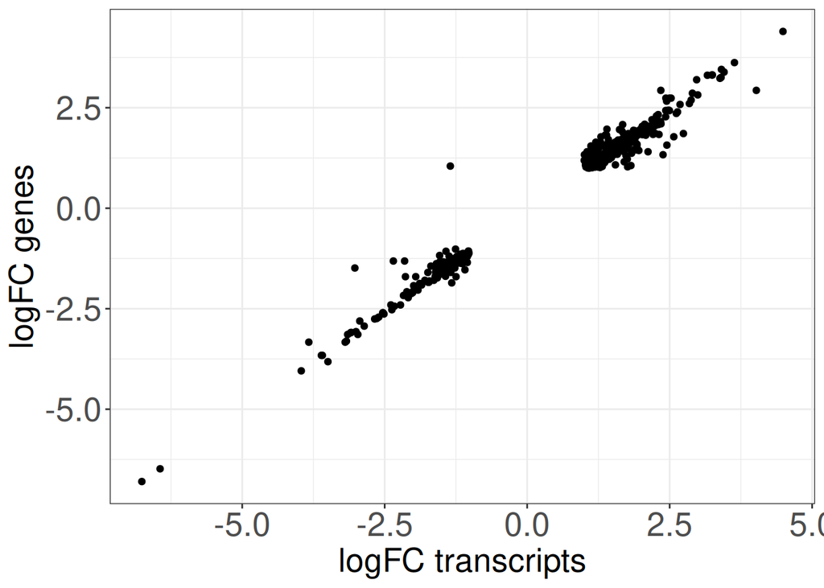

```r
sig_tx %>%
  dplyr::select(
    "Gene_txp" = "Gene",
    "logFC_txp" = "logFC") %>%
  left_join(sig_genes %>%
              dplyr::select(
                "Gene_gene" = "Gene",
                "logFC_gene" = "logFC"
              ),
            by = c("Gene_txp" = "Gene_gene")) %>%
  ggplot(
    aes(logFC_txp,
        logFC_gene)
    ) +
  geom_point() +
  xlab("logFC transcripts") +
  ylab("logFC genes") +
  theme_bw() +
  theme(axis.title = element_text(size = 20),
        axis.text = element_text(size = 20))
```

Seems only CSH2 has a conflicting logFC Good to see I still see this even now!